# week3

2024-03-13

# Bias

My primary concern with personal bias in this analysis is that I could try to explain occurrences using some irrelevant assumptions about the individuals involved in the shootings. I have tried to remain as objective and neutral as possible by offering explanations that apply to the population in general instead of focusing on particular sub-groups, except where relevant for the analysis (e.g. age).

Another possible source of bias is the methods by which the data was gathered, such as (intentionally or otherwise) intimidating witnesses, or using leading questions. Time of day may also affect data gathering since there are likely fewer witnesses at night (and fewer fully awake), which is also the time of day when the most shootings are recorded. The willingness of witnesses to provide testimony may also be a source of bias if they believe that their lives may be in danger by doing so.

The sample sizes are also of some concern as analyses are more easily biased by outliers in smaller groups.

# Analysis

First, we must load the shooting data from the City of New York website:

```r
shooting_data <- read_csv("https://data.cityofnewyork.us/api/views/833y-fsy8/rows.csv?accessType=DOWNLOAD", show_col_types = FALSE)
```

Next we can do some quick tidying of the data to eliminate columns that we’re not interested in and change the occurrence dates to a date type:

```r
tidy_shooting_data <- shooting_data %>%
  select(-c(INCIDENT_KEY, X_COORD_CD, Y_COORD_CD, Latitude, Longitude, Lon_Lat)) %>%
  mutate(OCCUR_DATE = mdy(OCCUR_DATE))
```

### Perp vs Victim by Age

Let’s say we want to know what the most likely pairings of shooter (perp) and victim (vic) are by age group. We can further filter the data to remove some entries that are most likely mistakes (no one lives to 1020 years old, for example), and entries that lack usable information (UNKNOWN and null). We can then easily group by perp and vic, summarizing by count:

```r
groups = c('<18', '18-24', '25-44', '45-64', '65+')

age_group_data <- tidy_shooting_data %>%
  filter(!(PERP_AGE_GROUP %in% c('1020', '224', '940', 'UNKNOWN', '(null)'))) %>%
  filter(!is.na(PERP_AGE_GROUP)) %>%
  filter(!(VIC_AGE_GROUP %in% c('1022', 'UNKNOWN'))) %>%
  group_by(PERP_AGE_GROUP, VIC_AGE_GROUP) %>%
  summarize(count=n())
```

Now that the data has been cleaned and grouped it’s easy to plot it:

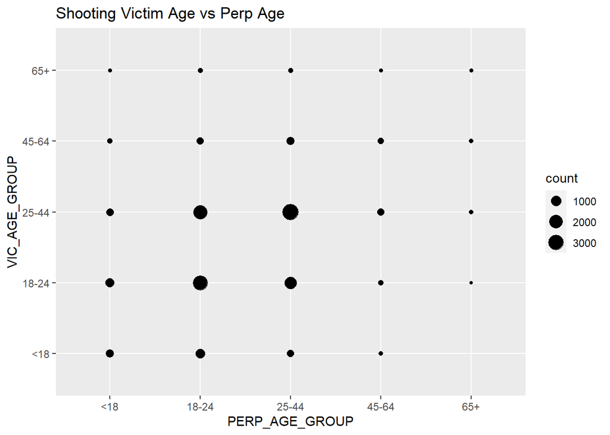

```r
age_group_data %>%
  ggplot(aes(x=PERP_AGE_GROUP, y=VIC_AGE_GROUP))+
  geom_point(aes(size=count))+
  labs(title='Shooting Victim Age vs Perp Age')
```

From the plot we can see an approximate symmetry about the diagonal, suggesting that age groups are likely to target each-other symmetrically.

### Cumulative Shootings by Perp Age over Time

What about shootings over time? Let’s arbitrarily select one age group (<18) and group the data by date, then generate a cumulative sum, and a linear model to approximate the data:

```r
perp_18_time_group <- tidy_shooting_data %>%
  filter(PERP_AGE_GROUP == '<18') %>%
  group_by(PERP_AGE_GROUP, OCCUR_DATE) %>%
  summarize(count=n()) %>%
  ungroup() %>%
  select(OCCUR_DATE, count) %>%
  arrange(OCCUR_DATE) %>%
  mutate(csum = cumsum(count))
age_model <- lm(csum ~ OCCUR_DATE, data=perp_18_time_group)
perp_18_time_group <- perp_18_time_group %>%
  mutate(pred=predict(age_model))

summary(age_model)
```

```
##
## Call:
## lm(formula = csum ~ OCCUR_DATE, data = perp_18_time_group)
##
## Residuals:
##     Min      1Q  Median      3Q     Max
## -157.23  -66.29   12.07   68.69  118.74
##
## Coefficients:
##               Estimate Std. Error t value Pr(>|t|)
## (Intercept) -2.947e+03  1.890e+01  -156.0   <2e-16 ***
## OCCUR_DATE   2.360e-01  1.179e-03   200.2   <2e-16 ***
## ---
## Signif. codes:  0 '***' 0.001 '**' 0.01 '*' 0.05 '.' 0.1 ' ' 1
##
## Residual standard error: 75.41 on 1134 degrees of freedom
## Multiple R-squared:  0.9725, Adjusted R-squared:  0.9725
## F-statistic: 4.009e+04 on 1 and 1134 DF,  p-value: < 2.2e-16
```

We can then use the data and model to compare the total instances of shooters in the <18 age group over time:

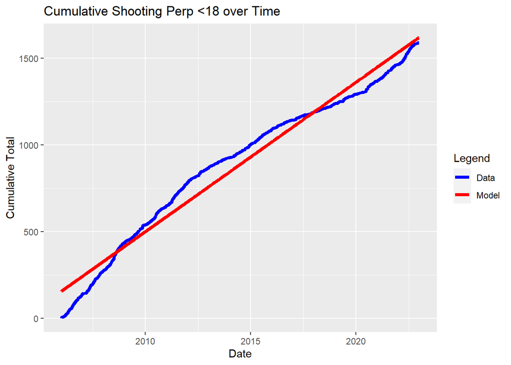

```r
colors <- c('Data' = 'blue', 'Model' = 'red')

perp_18_time_group %>%
  ggplot(aes(x=OCCUR_DATE))+
  geom_line(aes(y=csum, color='Data'), linewidth=1.5)+
  geom_line(aes(y=pred, color='Model'), linewidth=1.5)+
  labs(title='Cumulative Shooting Perp <18 over Time', x="Date", y='Cumulative Total', color='Legend')+
  scale_color_manual(values = colors)
```

The plot shows us that there is an approximately linear trend, suggesting that the rate of shooters in the <18 group is approximately constant over time. This may be contrary to expectations, since there are many factors (changes in populations, laws, cultural values, the overall economy, access to firearms, etc.), that might affect the prevalence of shootings in New York. It seems likely that the 16 years of data (2006-2022) simply don’t represent a long-enough time-span to observe more obvious deviations.

### Shootings by Location and Time of Day

Next we can investigate when (time of day) and where (inside or outside) shootings are most likely to occur. The data can be prepared using our previously cleaned data and filtering to only entries with location data, then grouping by location and time and summarizing:

```r
loc_group_data <- tidy_shooting_data %>%
  filter(!is.na(LOC_OF_OCCUR_DESC)) %>%
  group_by(LOC_OF_OCCUR_DESC, OCCUR_TIME) %>%
  summarize(count=n())
sum_by_loc <- loc_group_data %>%
  ungroup() %>%
  group_by(LOC_OF_OCCUR_DESC) %>%
  summarize(total=sum(count))
```

From this data we can generate a histogram showing the counts of occurrences by location and time of day:

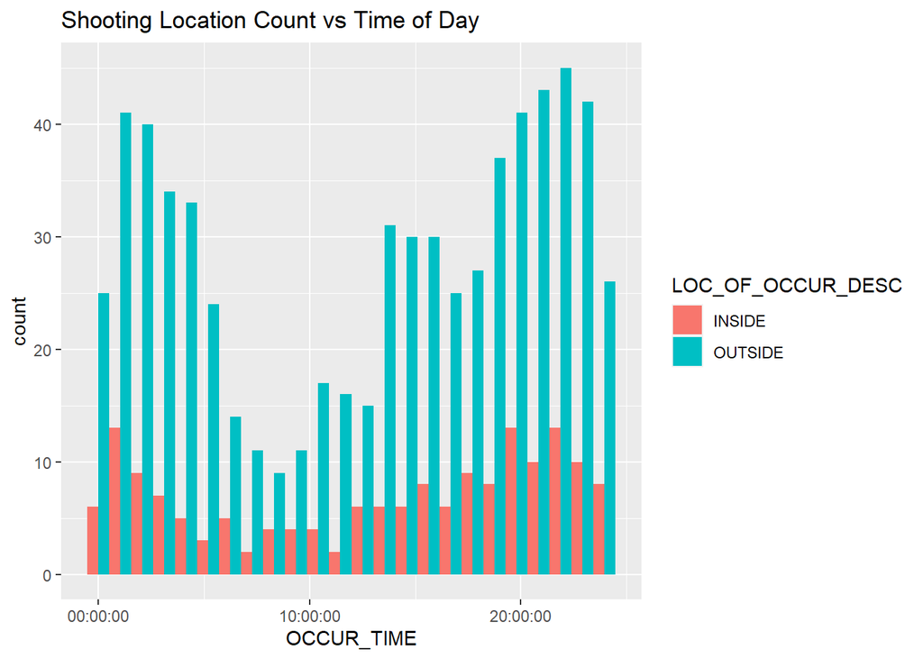

```r
loc_group_data %>%
  ggplot(aes(x=OCCUR_TIME))+
  geom_histogram(aes(fill=LOC_OF_OCCUR_DESC), bins=24, position='dodge')+
  labs(title='Shooting Location Count vs Time of Day')
```

However, since the two location subsets have different totals it makes them hard to compare via counts. We can generate a second histogram showing densities of occurrences instead, and overlay approximate curves for easier visualization:

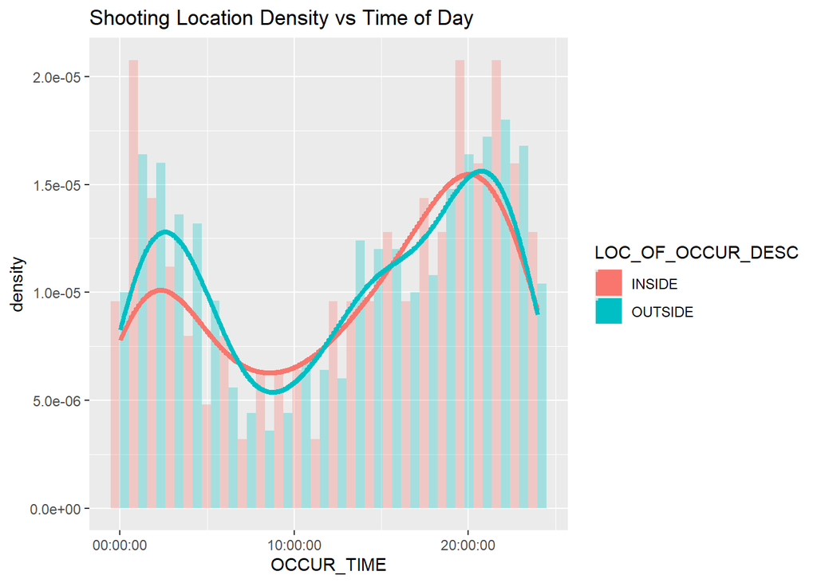

```r
loc_group_data %>%
  ggplot(aes(x=OCCUR_TIME))+
  geom_histogram(aes(y=after_stat(density), fill=LOC_OF_OCCUR_DESC), bins=24, position='dodge', alpha=0.3)+
  geom_density(aes(color=LOC_OF_OCCUR_DESC), linewidth=1.5)+
  labs(title='Shooting Location Density vs Time of Day')
```

From the resulting chart we can see an interesting trend where even though the count of outdoor shootings is higher than indoor shootings, they have a similar distribution over the time of day. We can also see a very distinctive dip in the middle of the graph, near approximately 9 AM, with another less exaggerated dip at midnight. This raises some questions about how the shooting data is reported/recorded. For example, is the dip near midnight because shooters have some preference for which day the shooting falls on? Is it because the people filing reports don’t want to do so in the middle of the night? There are many factors that could contribute. In general, we may be able to conclude that the shooters have a preference for night-time hours, which might be explained by having day-jobs, or using the darkness strategically.

### Shootings by Age and Time of Day

We can also perform an investigation on the relationship between time of day and the age of the shooter. This begins by again filtering and grouping our data:

```r
loc_age_time_group_data <- tidy_shooting_data %>%
  filter(!(PERP_AGE_GROUP %in% c('1020', '224', '940', 'UNKNOWN', '(null)'))) %>%
  filter(!is.na(PERP_AGE_GROUP)) %>%
  group_by(PERP_AGE_GROUP, OCCUR_TIME) %>%
  summarize(count=n())
```

From the data we can generate a similar histogram of occurrences vs time of day:

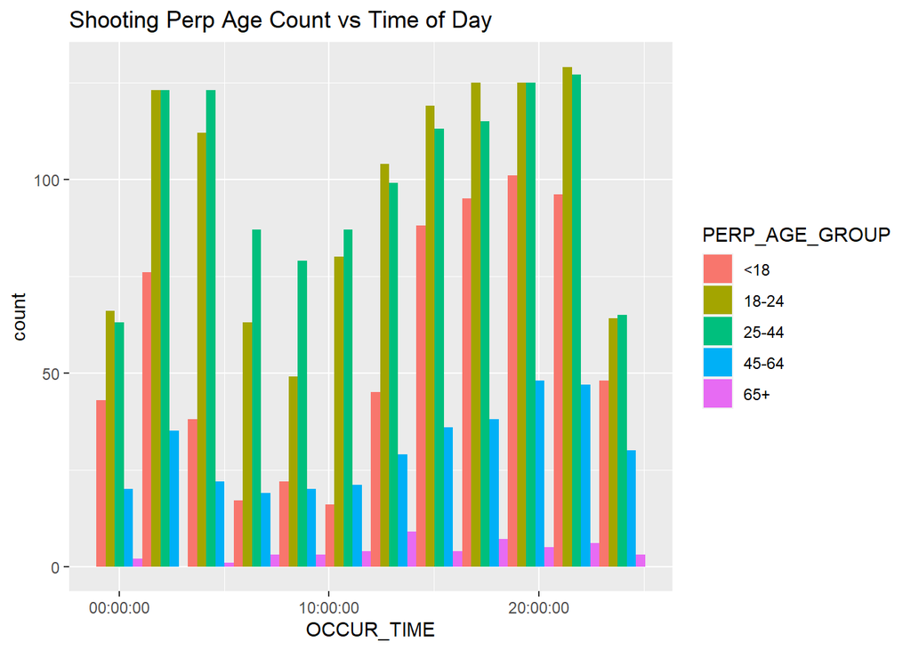

```r
loc_age_time_group_data %>%
  ggplot(aes(x=OCCUR_TIME))+
  geom_histogram(aes(fill=PERP_AGE_GROUP), bins=12, position='dodge')+
  labs(title='Shooting Perp Age Count vs Time of Day')
```

However, as we discovered earlier the totals per group can vary wildly in this data set, which makes comparison on the count-based histogram difficult. Instead, we can again generate a density-based graph for easier comparison:

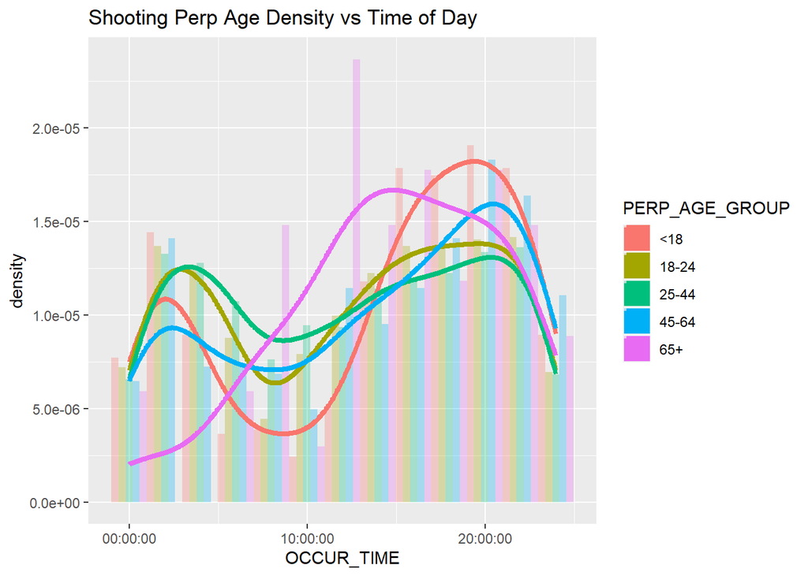

```r
loc_age_time_group_data %>%
  #filter(PERP_AGE_GROUP != '65+') %>%
  ggplot(aes(x=OCCUR_TIME))+
  geom_histogram(aes(y=after_stat(density), fill=PERP_AGE_GROUP), bins=13, position='dodge', alpha=0.3)+
  geom_density(aes(color=PERP_AGE_GROUP), linewidth=1.5)+
  labs(title='Shooting Perp Age Density vs Time of Day')
```

From this graph we can see, as we would expect, that the overall shape remains the same when compared to the indoor/outdoor vs time graph; a dip near approximately 9 AM and near midnight. Now that we can see the individual contributions by age group three interesting observations stand-out: the <18 group is the most heavily-exaggerated away from daylight-hours, which may be explainable by normal school hours keeping them under-watch and out of trouble. The second observations is that the 65+ group, which is the least-similar to the others, is relatively active during daylight hours and starts to fall-off sooner into the night. The third observations is that the largest groups per our first analysis (perp vs vic by age, groups 18-24 and 25-44) have very close curves suggesting that they are active around the same times (as would be required for such frequent conflict).